# Group 15: Poland-bankruptcy-data-2009

## Members that contributed:

### Student Number: 578674

### Student Number: 578403

# 1. Loading and preparing data

### 1.1 Loading data

```python
# !pip install category_encoders
import warnings
import pandas as pd
import numpy as np
import gzip
import json
import matplotlib.pyplot as plt
import seaborn as sns
from imblearn.over_sampling import RandomOverSampler
from sklearn.model_selection import GridSearchCV, cross_val_score, train_test_split
from sklearn.metrics import (
    ConfusionMatrixDisplay,
    classification_report,
    confusion_matrix,
)
from sklearn.pipeline import make_pipeline
warnings.simplefilter(action="ignore", category=FutureWarning)
import matplotlib.pyplot as plt
```

```python
with gzip.open("./poland-bankruptcy-data-2009.json.gz", "r") as f:
        data = json.load(f)
```

Keys from our JSON format data

```python
data.keys()
```

```
dict_keys(['schema', 'data', 'metadata'])
```

Number of instances

```python
len(data['data'])
```

```
9977
```

Number of features

```python
len(data['data'][0])
```

```
66
```

```python
type(data)
df = pd.DataFrame().from_dict(data['data']).set_index('company_id')
df.head()
```

| company_id | feat_1 | feat_2 | feat_3 | feat_4 | feat_5 | feat_6 | feat_7 | feat_8 | feat_9 | feat_10 | ... | feat_56 | feat_57 | feat_58 | feat_59 | feat_60 | feat_61 | feat_62 | feat_63 | feat_64 | bankrupt |
| --- | --- | --- | --- | --- | --- | --- | --- | --- | --- | --- | --- | --- | --- | --- | --- | --- | --- | --- | --- | --- | --- |
| 1 | 0.174190 | 0.41299 | 0.14371 | 1.3480 | -28.9820 | 0.60383 | 0.219460 | 1.12250 | 1.1961 | 0.46359 | ... | 0.163960 | 0.375740 | 0.83604 | 0.000007 | 9.7145 | 6.2813 | 84.291 | 4.3303 | 4.0341 | False |
| 2 | 0.146240 | 0.46038 | 0.28230 | 1.6294 | 2.5952 | 0.00000 | 0.171850 | 1.17210 | 1.6018 | 0.53962 | ... | 0.027516 | 0.271000 | 0.90108 | 0.000000 | 5.9882 | 4.1103 | 102.190 | 3.5716 | 5.9500 | False |
| 3 | 0.000595 | 0.22612 | 0.48839 | 3.1599 | 84.8740 | 0.19114 | 0.004572 | 2.98810 | 1.0077 | 0.67566 | ... | 0.007639 | 0.000881 | 0.99236 | 0.000000 | 6.7742 | 3.7922 | 64.846 | 5.6287 | 4.4581 | False |
| 5 | 0.188290 | 0.41504 | 0.34231 | 1.9279 | -58.2740 | 0.00000 | 0.233580 | 1.40940 | 1.3393 | 0.58496 | ... | 0.176480 | 0.321880 | 0.82635 | 0.073039 | 2.5912 | 7.0756 | 100.540 | 3.6303 | 4.6375 | False |
| 6 | 0.182060 | 0.55615 | 0.32191 | 1.6045 | 16.3140 | 0.00000 | 0.182060 | 0.79808 | 1.8126 | 0.44385 | ... | 0.555770 | 0.410190 | 0.46957 | 0.029421 | 8.4553 | 3.3488 | 107.240 | 3.4036 | 12.4540 | False |

5 rows × 65 columns

```python
df.info()
```

```
<class 'pandas.core.frame.DataFrame'>
Int64Index: 9977 entries, 1 to 10503
Data columns (total 65 columns):
 #   Column    Non-Null Count  Dtype
---  ------    --------------  -----
 0   feat_1    9977 non-null   float64
 1   feat_2    9977 non-null   float64
 2   feat_3    9977 non-null   float64
 3   feat_4    9960 non-null   float64
 4   feat_5    9952 non-null   float64
 5   feat_6    9977 non-null   float64
 6   feat_7    9977 non-null   float64
 7   feat_8    9964 non-null   float64
 8   feat_9    9974 non-null   float64
 9   feat_10   9977 non-null   float64
```

[output cut: 57 more lines]

### 1.2 Preparing data

#### Checking for null values

```python
total = df.isnull().sum().sort_values(ascending=False)
percent = ((df.isnull().sum()/df.isnull().count()).sort_values(ascending=False))*100
missing_data = pd.concat([total, percent], axis=1, keys=['Total', 'Percent'])
missing_data.head(20)
```

|  | Total | Percent |
| --- | --- | --- |
| feat_37 | 4478 | 44.883231 |
| feat_21 | 772 | 7.737797 |
| feat_27 | 665 | 6.665330 |
| feat_60 | 562 | 5.632956 |
| feat_45 | 561 | 5.622933 |
| feat_24 | 213 | 2.134910 |
| feat_53 | 212 | 2.124887 |
| feat_28 | 212 | 2.124887 |
| feat_54 | 212 | 2.124887 |
| feat_64 | 212 | 2.124887 |
| feat_41 | 190 | 1.904380 |
| feat_32 | 96 | 0.962213 |
| feat_47 | 81 | 0.811867 |
| feat_52 | 81 | 0.811867 |
| feat_20 | 42 | 0.420968 |
| feat_30 | 42 | 0.420968 |
| feat_49 | 42 | 0.420968 |
| feat_23 | 42 | 0.420968 |
| feat_56 | 42 | 0.420968 |
| feat_39 | 42 | 0.420968 |

None of the columns have a particular high amount of null values (> 50%). Thus no columns will be dropped.

```python
df['bankrupt'].value_counts()/len(df)*100
```

```
False    95.319234
True      4.680766
Name: bankrupt, dtype: float64
```

As you can see, the number of True instances in the Data Set is less that 5% compared to the number of False instances in the Data Set which implies it is heavily imbalanced and that removing rows can further increase that imbalance. Thus no null instances were dropped.

Getting all the columns of type number

```python
num_cols = df.select_dtypes(include=['number']).columns
num_cols
```

```
Index(['feat_1', 'feat_2', 'feat_3', 'feat_4', 'feat_5', 'feat_6', 'feat_7',
       'feat_8', 'feat_9', 'feat_10', 'feat_11', 'feat_12', 'feat_13',
       'feat_14', 'feat_15', 'feat_16', 'feat_17', 'feat_18', 'feat_19',
       'feat_20', 'feat_21', 'feat_22', 'feat_23', 'feat_24', 'feat_25',
       'feat_26', 'feat_27', 'feat_28', 'feat_29', 'feat_30', 'feat_31',
       'feat_32', 'feat_33', 'feat_34', 'feat_35', 'feat_36', 'feat_37',
       'feat_38', 'feat_39', 'feat_40', 'feat_41', 'feat_42', 'feat_43',
       'feat_44', 'feat_45', 'feat_46', 'feat_47', 'feat_48', 'feat_49',
       'feat_50', 'feat_51', 'feat_52', 'feat_53', 'feat_54', 'feat_55',
       'feat_56', 'feat_57', 'feat_58', 'feat_59', 'feat_60', 'feat_61',
       'feat_62', 'feat_63', 'feat_64'],
      dtype='object')
```

Removing all null values by replacing them with the mean values of their respective column

```python
from sklearn.impute import SimpleImputer

# Create imputers for numerical columns
num_imputer = SimpleImputer(strategy='mean')

# apply the imputer to the selected columns
df[num_cols] = num_imputer.fit_transform(df[num_cols])
```

```python
df.shape
```

```
(9977, 65)
```

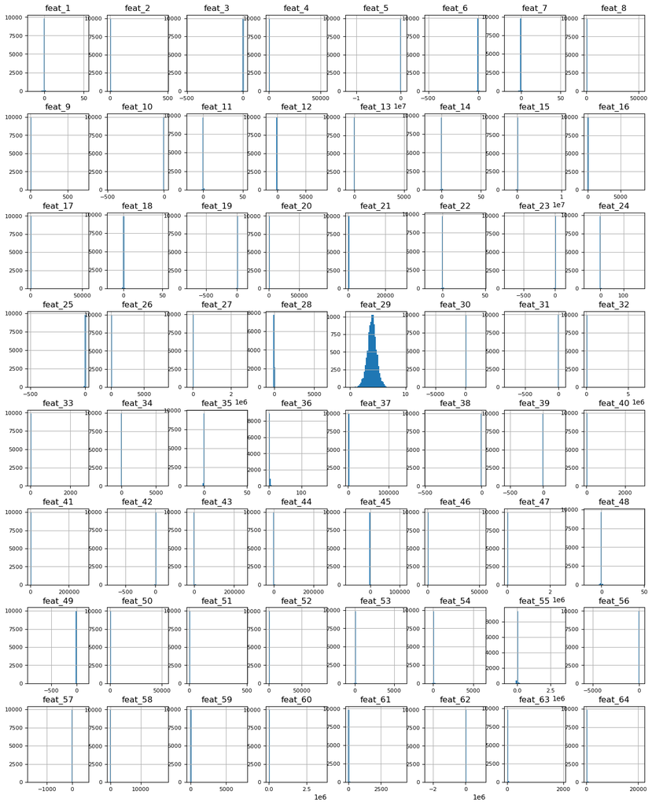

```python
df_hist=df.select_dtypes(include=['float64','int64', 'object'])
df_hist.hist(figsize=(16,20),bins=50,xlabelsize=8,ylabelsize=8);
```

```python
df.shape
```

```
(9977, 65)
```

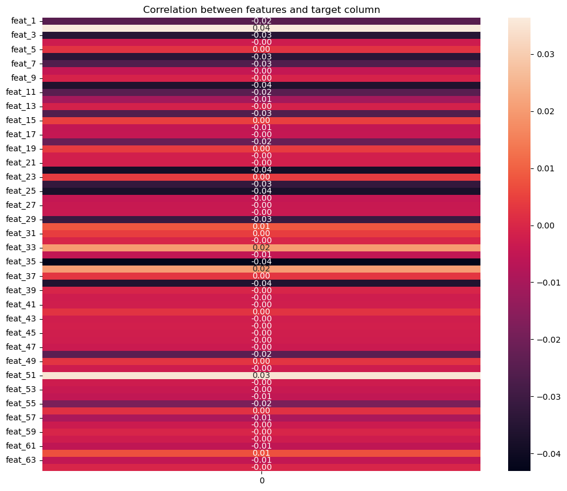

```python
#Get correlation between features and target column
X = df.drop('bankrupt', axis =1)
y = df['bankrupt']
fig, ax = plt.subplots(figsize=(12,10))
corr_matrix = X.corrwith(y)
sns.heatmap(corr_matrix.to_frame(), annot=True, fmt='.2f')
plt.title('Correlation between features and target column')
plt.show()
```

The above feat rows in the heat map shows that the features have a low positive and negative correlation with the target column with most of them having negative correlation. Thus meaning that no feature has a strong linear correlation with the target value and models such as Linear Regression will not suite this Data Set

## Preportion between the number of 'False' and 'True' instances

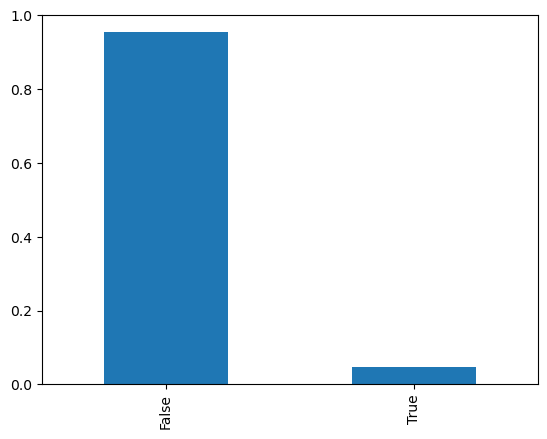

```python
df.bankrupt.value_counts(normalize=True).plot(kind='bar');
```

## 2. Train-test split

```python
target = "bankrupt"
X = df.drop(columns=target)
y = df[target]

print("X shape:", X.shape)
print("y shape:", y.shape)
```

```
X shape: (9977, 64)
y shape: (9977,)
```

```python
X_train, X_test, y_train, y_test = train_test_split(X, y, test_size=0.2, random_state=42)
```

Print the shapes of the training and testing sets

```python
print("X_train shape:", X_train.shape)
print("y_train shape:", y_train.shape)
print("X_test shape:", X_test.shape)
print("y_test shape:", y_test.shape)
```

```
X_train shape: (7981, 64)
y_train shape: (7981,)
X_test shape: (1996, 64)
y_test shape: (1996,)
```

## 3. Resampling technique

The Poland bankruptcy dataset is a binary classification problem where the positive class (bankruptcy) is severely under-represented, making it a heavily imbalanced dataset. In such cases, RandomOverSampler can be a good option as it is a simple technique that can effectively balance the dataset by randomly duplicating the minority class samples until a balanced class distribution is achieved.

To address class imbalance, we used the RandomOverSampler resampling technique using the sampling_strategy = 'minority' parameter to help correct imbalance.This randomly oversamples the minority class to balance the dataset. We chose this technique because it does not discard any data and can increase the overall performance of the model.

### It is important to notice that resampleing must occur after the splitting of data in a training and testing set. This is because if resampling is done on the entire data set then data leakage will occur and essentially heavily overfit your model causing results such as 100% on all scores

Create RandomOverSampler object

```python
from imblearn.over_sampling import RandomOverSampler
ros = RandomOverSampler(random_state=42, sampling_strategy = 'minority')
```

Resample the data

```python
X_resampled, y_resampled = ros.fit_resample(X_train, y_train)
```

### Updated preportion after oversampling has occured

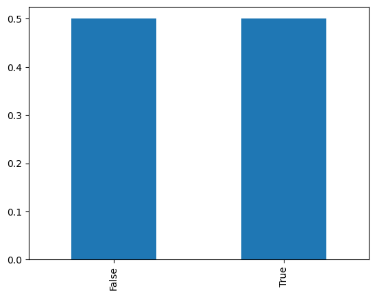

```python
y_resampled.value_counts(normalize = True).plot(kind = 'bar')
```

## 4. Hyperparameter tuning

### Gradient boosting without hyperparameters

```python
from sklearn.ensemble import GradientBoostingClassifier
from sklearn.metrics import accuracy_score, precision_score, recall_score, f1_score, roc_curve, roc_auc_score, confusion_matrix
```

```python
gb = GradientBoostingClassifier(random_state=42)
```

```python
gb.fit(X_resampled, y_resampled)
```

```
GradientBoostingClassifier(random_state=42)
```

Make predictions on test set

```python
y_pred = gb.predict(X_test)
```

### Evaluating model

Calculate evaluation metrics

```python
accuracy_untunned = round(accuracy_score(y_test, y_pred),2)
precision_untunned = round(precision_score(y_test, y_pred),2)
recall_untunned = round(recall_score(y_test, y_pred),2)
f1_untunned = round(f1_score(y_test, y_pred),2)
roc_auc_untunned = round(roc_auc_score(y_test, y_pred),2)
cm = confusion_matrix(y_test, y_pred)
```

Print evaluation metrics

```python
table_data = {
    'Accuracy': [accuracy_untunned],
    'Precision': [precision_untunned],
    'Recall': [recall_untunned],
    'F1 score': [f1_untunned],
    'ROC AUC score': [roc_auc_untunned]
    }
results_df = pd.DataFrame(table_data)
results_df.head()
```

|  | Accuracy | Precision | Recall | F1 score | ROC AUC score |
| --- | --- | --- | --- | --- | --- |
| 0 | 0.91 | 0.28 | 0.72 | 0.4 | 0.82 |

Confusion matrix on test data

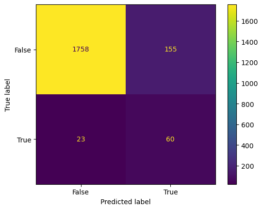

```python
cm1 = confusion_matrix(y_test, y_pred)
label_names = ['False', 'True']
disp = ConfusionMatrixDisplay(confusion_matrix=cm1,display_labels=label_names)
disp.plot();
```

### Gradient boosting with hyperparameters

```python
from sklearn.model_selection import GridSearchCV
from sklearn.ensemble import GradientBoostingClassifier
from sklearn.metrics import classification_report
import numpy as np
```

Define the hyperparameter space

```python
param_grid = {
    'learning_rate': [ 0.1, 0.5, 1],
    'n_estimators': [100,150,200],
    'max_depth': [8, 10, 12],
    'min_samples_split': [3, 4, 5],
    'min_samples_leaf': [4, 5, 6],
    'max_features': [1.0, 'sqrt', 'log2']
}
```

Use GridSearchCV to identify best parameters

```python
grid_search = GridSearchCV(estimator=gb, param_grid=param_grid,n_jobs=-1, cv=5)
```

Fit the model

```python
grid_search.fit(X_resampled, y_resampled)
```

[output not shown]

Print the best hyperparameters

```python
print("Best hyperparameters: ")
print(grid_search.best_params_)
```

```
Best hyperparameters:
{'learning_rate': 0.1, 'max_depth': 12, 'max_features': 1.0, 'min_samples_leaf': 5, 'min_samples_split': 3, 'n_estimators': 200}
```

Predict on the test set using the best hyperparameters

```python
y_pred = grid_search.predict(X_test)
```

```python
print(y_pred)
```

```
[False False False ... False False False]
```

### Evaluating tuned model

```python
from sklearn.metrics import accuracy_score, precision_score, recall_score, f1_score
```

Calculate evaluation metrics

```python
accuracy = round(accuracy_score(y_test, y_pred),2)
precision = round(precision_score(y_test, y_pred),2)
recall = round(recall_score(y_test, y_pred),2)
f1 = round(f1_score(y_test, y_pred),2)
roc_auc = round(roc_auc_score(y_test, y_pred),2)
cm = confusion_matrix(y_test, y_pred)
```

Print evaluation metrics

```python
table_data = {
    'Accuracy': [accuracy],
    'Precision': [precision],
    'Recall': [recall],
    'F1 score': [f1],
    'ROC AUC score': [roc_auc]
    }
results_df = pd.DataFrame(table_data)
results_df.head()
```

|  | Accuracy | Precision | Recall | F1 score | ROC AUC score |
| --- | --- | --- | --- | --- | --- |
| 0 | 0.97 | 0.79 | 0.36 | 0.5 | 0.68 |

Confusion matrix on test data

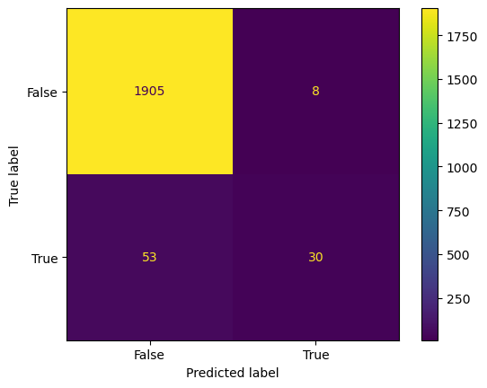

```python
cm2 = confusion_matrix(y_test, y_pred)
label_names = ['False', 'True']
disp = ConfusionMatrixDisplay(confusion_matrix=cm2,display_labels=label_names)
disp.plot();
```

# 5. Feature importance analysis (5 marks)

```python
importances = grid_search.best_estimator_.feature_importances_
feature_names = X_resampled.columns
indices = np.argsort(importances)[::-1]
top_indices = indices[:10]
```

```python
top_features = pd.DataFrame({'Feature': feature_names[top_indices], 'Importance': importances[top_indices]})
top_features.head(10)
```

|  | Feature | Importance |
| --- | --- | --- |
| 0 | feat_34 | 0.117514 |
| 1 | feat_27 | 0.107045 |
| 2 | feat_24 | 0.082582 |
| 3 | feat_26 | 0.073148 |
| 4 | feat_21 | 0.065940 |
| 5 | feat_58 | 0.041462 |
| 6 | feat_46 | 0.036575 |
| 7 | feat_5 | 0.035327 |
| 8 | feat_38 | 0.032860 |
| 9 | feat_39 | 0.025016 |

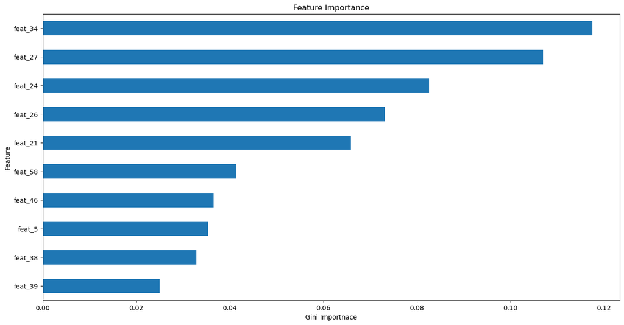

```python
#Create a series of feature importance
feature_imp = pd.Series(importances, index = feature_names).sort_values(ascending=True)
#Plot features on a horizontal bar chart
feature_imp.tail(10).plot(kind = 'barh', figsize = [16, 8])
plt.xlabel('Gini Importnace')
plt.ylabel('Feature');
plt.title('Feature Importance')
```

```python
top_10_features = feature_names
X_train_top = X_resampled[top_10_features]
X_test_top = X_test[top_10_features]
```

```python
model_top = GradientBoostingClassifier(**grid_search.best_params_,random_state=42)
#model_top = GradientBoostingClassifier(random_state=42)
model_top.fit(X_train_top, y_resampled)
```

```
GradientBoostingClassifier(max_depth=12, max_features=1.0, min_samples_leaf=5,
                           min_samples_split=3, n_estimators=200,
                           random_state=42)
```

# 6. Final model evaluation

Evaluate the model on the testing set

```python
y_pred_top = model_top.predict(X_test_top)
accuracy_top = round(accuracy_score(y_test, y_pred_top),2)
precision_top = round(precision_score(y_test, y_pred_top),2)
recall_top = round(recall_score(y_test, y_pred_top),2)
f1_score_top = round(f1_score(y_test, y_pred_top),2)
roc_auc_top = round(roc_auc_score(y_test, y_pred_top),2)
cm = confusion_matrix(y_test, y_pred_top)
```

Predict on the test set using the best hyperparameters and top features

```python
print(y_pred_top)
```

```
[False False False ... False False False]
```

Report the evaluation metrics

```python
table_data = {
    'Accuracy': [accuracy_top],
    'Precision': [precision_top],
    'Recall': [recall_top],
    'F1 score': [f1_score_top],
    'ROC AUC score': [roc_auc_top]
    }
results_df = pd.DataFrame(table_data)
results_df.head()
```

|  | Accuracy | Precision | Recall | F1 score | ROC AUC score |
| --- | --- | --- | --- | --- | --- |
| 0 | 0.97 | 0.79 | 0.36 | 0.5 | 0.68 |

These metrics suggest that the model has a high accuracy which means that the model is able to classify a high percentage of samples correctly.

The precision score in this evaluation is realitively high which indicates that a large majority of the predicted positive cases were actually positive.

Although the recall score is lower,which means that the model is not able to identify many of the positive cases correctly.

The F1 score provides a balanced assessment of precision and recall.

Confusion matrix on test data

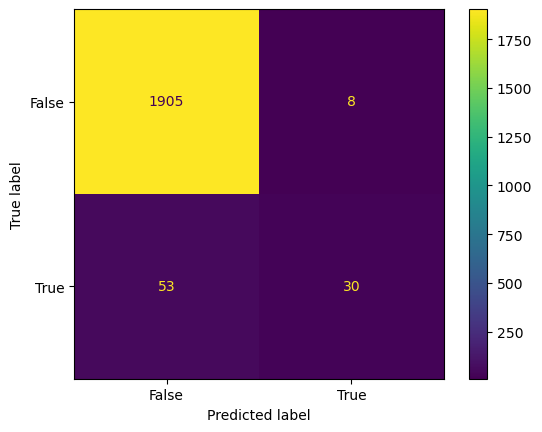

```python
cm3 = confusion_matrix(y_test, y_pred_top)
label_names = ['False', 'True']
disp = ConfusionMatrixDisplay(confusion_matrix=cm3,display_labels=label_names)
disp.plot();
```

The confusion matrix above shows that there were a total of 1996 predictions made. Out of those, 1905 were true negative predictions (i.e., the model correctly identified negative cases), and 30 were true positive predictions (i.e., the model correctly identified positive cases). However, the model also made 53 false negative predictions (i.e., the model predicted negative, but the actual value was positive) and 8 false positive predictions (i.e., the model predicted positive, but the actual value was negative).

In this case, the model has a high number of true negatives, indicating that it is good at identifying negative cases. However, it has a relatively low number of true positives, suggesting that it struggles to correctly identify positive cases. The number of false negatives is also notable, indicating that the model is failing to identify some positive cases.

# 7. Reporting (10 marks)

### Loading data

We loaded the data from poland-bankruptcy-data-2009 by unzipping the zipped file with gzip library, then converting the json file type to a dataframe with pd.DataFrame which is from pandas library.

### Preparing data

We checked for null values and replaced with the mean using SimpleImputer. We chose to replace the nulls with the mean as removing Nulls caused a increase in the imbalance of the dataset as the amount of true values fro the entire dataset went from 4% to 1% and false values from 96% to 99%. We used a heat map matrix to view the Correlation between features and target column and determined that there was a low or negative correlation with all features.

### Hyperparameter tuning

We used GridSearchCV to perform hyperparameter tuning for the GradientBoostingClassifier algorithm, and found that the optimal parameters were: (max_depth=12, max_features=1.0, min_samples_leaf=5, min_samples_split=3, n_estimators=200)

learning_rate: The learning rate shrinks the contribution of each tree by a factor of learning_rate in order to reduce overfitting.

n_estimators: The number of boosting stages to perform. This corresponds to the number of trees in the model.

max_depth: The maximum depth of each decision tree in the ensemble. The higher the max_depth the more complex the model which in return increases over-fitting.

min_samples_split: The minimum number of samples required to split an internal node. This helps to avoid overfitting by requiring a minimum number of samples to be present in a node before it can be split.

min_samples_leaf: The minimum number of samples required to be at a leaf node. A leaf node is a node without any children. This helps to avoid overfitting by requiring a minimum number of samples to be present at the end of a branch.

max_features: The number of features to consider when looking for the best split.

The model achieved an accuracy of 0.97 , precision of 0.79 , recall of 0.36, and an F1-score of 0.5 on the testing set.

### Feature importance and Feature importance analysis

We also computed the feature importance of the model, and found that the top 10 most important features were:

(feat_34, feat_27, feat_24, feat_26, feat_21, feat_58, feat_46, feat_5, feat_38, feat_39)

Based on the determined features and what they are defined as on the http://archive.ics.uci.edu/ml/datasets/polish+companies+bankruptcy+data website we determined that:

feat_34: The ratio of operating expenses to total liabilities is an important indicator. Higher values of this feature suggest higher operating expenses relative to the company's total liabilities.

feat_27: The ratio of profit on operating activities to financial expenses is an important factor. It indicates the profitability of the company's core operations relative to its financial expenses.

feat_24: The ratio of gross profit over a period of three years to total assets is a significant measure. It provides insights into the company's long-term profitability in relation to its total assets.

feat_26: The ratio of net profit plus depreciation to total liabilities is a crucial metric. It reflects the company's financial stability by considering its net profit and depreciation relative to its total liabilities.

feat_21: The sales growth rate is an important feature. It compares the current period's sales to the sales of the previous period, indicating the company's performance in terms of revenue growth.

feat_58: The ratio of total costs to total sales is an insightful measure. It indicates the efficiency of cost management in relation to the company's revenue generation.

feat_46: The ratio of current assets minus inventory to short-term liabilities is a significant indicator. It reflects the company's ability to cover its short-term obligations using its current assets excluding inventory.

feat_5: This feature represents a complex calculation involving cash, short-term securities, receivables, short-term liabilities, operating expenses, and depreciation. It provides insights into the company's cash flow management and profitability over a year.

feat_38: The ratio of constant capital to total assets is an important measure. It assesses the company's financial structure by considering its constant capital (a long-term funding source) relative to its total assets.

feat_39: The ratio of profit on sales to sales is a significant performance indicator. It measures the company's profitability per unit of sales and highlights its ability to generate profits from its revenue.

Overall, the feature importance analysis helps us understand the most important financial indicators that impact a company's likelihood of bankruptcy. By paying close attention to these indicators, companies can better manage their financial health and reduce their risk of bankruptcy.

### Comparing confusion heat matrixes

Compared the confusion matrixes of the 3 models, Gradient Boost, Gradient Boost Tuned and top-10 Gradient tuned.

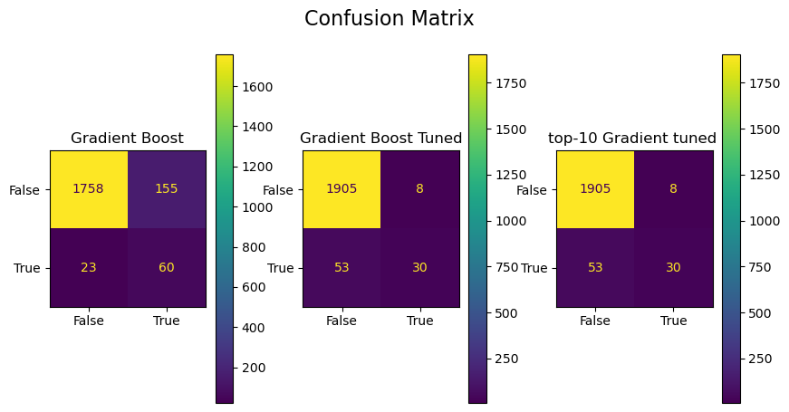

```python
fig, ax = plt.subplots(1, 3, figsize=(10, 5))
fig.subplots_adjust(wspace=0.3)

# plot the first confusion matrix on the left subplot
disp1 = ConfusionMatrixDisplay(confusion_matrix=cm1,display_labels=label_names).plot(ax=ax[0])
ax[0].set_title("Gradient Boost")
ax[0].set_xlabel('')
ax[0].set_ylabel('')


# plot the second confusion matrix on the right subplot
disp2 = ConfusionMatrixDisplay(confusion_matrix=cm2,display_labels=label_names).plot(ax=ax[1])
ax[1].set_title("Gradient Boost Tuned")
ax[1].set_xlabel('')
ax[1].set_ylabel('')


# plot the second confusion matrix on the right subplot
disp2 = ConfusionMatrixDisplay(confusion_matrix=cm3,display_labels=label_names).plot(ax=ax[2])
ax[2].set_title("top-10 Gradient tuned ")
ax[2].set_xlabel('')
ax[2].set_ylabel('')


# set the main title for all three plots
plt.suptitle("Confusion Matrix", fontsize=16)
# show the plot
plt.show()
```

Comparing the models, we can observe the following:

The initial Gradient Boost model had a higher number of true positives (60), but it also had a higher number of false positives (155) compared to the other two models. This indicates that it was more likely to incorrectly predict positive cases.

After tuning the Gradient Boost model, the number of true positives decreased to 30, while the number of false positives decreased to 8. This suggests that the model became more conservative in predicting positive cases, resulting in a lower number of false positives.

The Top-10 Gradient Tuned model shows the same performance as the tuned Gradient Boost model, with 30 true positives and 8 false positives.

### Comparing metrics

Set evaluation metrics

```python
table_data = {
    'Model': ['Gradient boost', 'Tunned Gradient boost ','Tunned Gradient boost with top 10 '],
    'Accuracy': [accuracy_untunned,accuracy, accuracy_top],
    'Precision': [precision_untunned,precision,precision_top],
    'Recall': [recall_untunned,recall,recall_top],
    'F1 score': [f1_untunned,f1,f1_score_top],
    'ROC AUC score': [roc_auc_untunned,roc_auc,roc_auc_top]
    }
```

Print evaluation metrics

```python
results_df = pd.DataFrame(table_data)
results_df.head()
```

|  | Model | Accuracy | Precision | Recall | F1 score | ROC AUC score |
| --- | --- | --- | --- | --- | --- | --- |
| 0 | Gradient boost | 0.91 | 0.28 | 0.72 | 0.4 | 0.82 |
| 1 | Tunned Gradient boost | 0.97 | 0.79 | 0.36 | 0.5 | 0.68 |
| 2 | Tunned Gradient boost with top 10 | 0.97 | 0.79 | 0.36 | 0.5 | 0.68 |

Accuracy: It represents the overall correctness of the model's predictions. Higher accuracy indicates a higher proportion of correct predictions.

Precision: It measures the proportion of correctly predicted positive instances out of the total predicted positive instances. A higher precision means a lower rate of false positives.

Recall: It measures the proportion of correctly predicted positive instances out of the actual positive instances. A higher recall means a lower rate of false negatives.

F1 Score: It is the harmonic mean of precision and recall and provides a single metric to evaluate the model's performance, considering both precision and recall.

ROC AUC Score: It measures the model's ability to distinguish between positive and negative classes, where a higher score indicates better performance.